title: “IP_Week_14” author: “Farnadis_Kanja” date: “2/5/2022” output: html_document Define the Question A Kenyan entrepreneur has created an online cryptography course and would want to advertise it on her blog. She currently targets audiences originating from various countries. In the past, she ran ads to advertise a related course on the same blog and collected data in the process. She would now like to employ your services as a Data Science Consultant to help her identify which individuals are most likely to click on her ads. We need to come up with a model which can predict the likelihood of an individual clicking on her advertisements

Metric of Success To achieve this, we will need to look at the accuracy of our model. We aim for an accuracy of at least 96%

The Context The dataset shows the various characteristics of people that had visited a blog. These characteristics are the country, the city, whether they clicked on the ad, time spent on the site, amount of internet used, as well as their gender.

Experimental design taken We used the SVM model in supervised learning to approach this issue since this is a problem of classification. We used the R programning language

Appropriateness of the Available Data It was a bit difficult to determine the appropriateness of this data

R Notebook

Let’s begin by installing dependencies and their libraries

```r
install.packages("data.table") # install package data.table to work with data tables
library("data.table")
```

*Data Loading*

```r
install.packages("tidyverse") # install packages to work with data frame - extends into visualization
library(tidyverse)
```

Let’s now load our data accordingly and preview our data set

```r
advertising_dataset <- fread('http://bit.ly/IPAdvertisingData')
head(advertising_dataset)
```

```
##    Daily Time Spent on Site Age Area Income Daily Internet Usage
## 1:                    68.95  35    61833.90               256.09
## 2:                    80.23  31    68441.85               193.77
## 3:                    69.47  26    59785.94               236.50
## 4:                    74.15  29    54806.18               245.89
## 5:                    68.37  35    73889.99               225.58
## 6:                    59.99  23    59761.56               226.74
##                            Ad Topic Line           City Male    Country
## 1:    Cloned 5thgeneration orchestration    Wrightburgh    0    Tunisia
## 2:    Monitored national standardization      West Jodi    1      Nauru
## 3:      Organic bottom-line service-desk       Davidton    0 San Marino
## 4: Triple-buffered reciprocal time-frame West Terrifurt    1      Italy
## 5:         Robust logistical utilization   South Manuel    0    Iceland
## 6:       Sharable client-driven software      Jamieberg    1     Norway
##              Timestamp Clicked on Ad
## 1: 2016-03-27 00:53:11             0
## 2: 2016-04-04 01:39:02             0
## 3: 2016-03-13 20:35:42             0
## 4: 2016-01-10 02:31:19             0
## 5: 2016-06-03 03:36:18             0
## 6: 2016-05-19 14:30:17             0
```

Let us look at the various properties of the dataset Let’s look at the data types

```r
sapply(advertising_dataset,class)
```

```
## $`Daily Time Spent on Site`
## [1] "numeric"
##
## $Age
## [1] "integer"
##
## $`Area Income`
## [1] "numeric"
##
## $`Daily Internet Usage`
## [1] "numeric"
##
## $`Ad Topic Line`
## [1] "character"
##
## $City
## [1] "character"
##
## $Male
## [1] "integer"
##
## $Country
## [1] "character"
##
## $Timestamp
## [1] "POSIXct" "POSIXt"
##
## $`Clicked on Ad`
## [1] "integer"
```

Let’s change timestamp to date

```r
advertising_dataset$Timestamp <-as.Date(advertising_dataset$Timestamp, format = "%Y-%m-%s-%h-%m -%s")
#checking if the change has been implemented
sapply(advertising_dataset,class)
```

```
## Daily Time Spent on Site                      Age              Area Income
##                "numeric"                "integer"                "numeric"
##     Daily Internet Usage            Ad Topic Line                     City
##                "numeric"              "character"              "character"
##                     Male                  Country                Timestamp
##                "integer"              "character"                   "Date"
##            Clicked on Ad
##                "integer"
```

```r
str(advertising_dataset)
```

```
## Classes 'data.table' and 'data.frame':   1000 obs. of  10 variables:
##  $ Daily Time Spent on Site: num  69 80.2 69.5 74.2 68.4 ...
##  $ Age                     : int  35 31 26 29 35 23 33 48 30 20 ...
##  $ Area Income             : num  61834 68442 59786 54806 73890 ...
##  $ Daily Internet Usage    : num  256 194 236 246 226 ...
##  $ Ad Topic Line           : chr  "Cloned 5thgeneration orchestration" "Monitored national standardization" "Organic bottom-line service-desk" "Triple-buffered reciprocal time-frame" ...
##  $ City                    : chr  "Wrightburgh" "West Jodi" "Davidton" "West Terrifurt" ...
##  $ Male                    : int  0 1 0 1 0 1 0 1 1 1 ...
##  $ Country                 : chr  "Tunisia" "Nauru" "San Marino" "Italy" ...
##  $ Timestamp               : Date, format: "2016-03-27" "2016-04-04" ...
##  $ Clicked on Ad           : int  0 0 0 0 0 0 0 1 0 0 ...
##  - attr(*, ".internal.selfref")=<externalptr>
```

```r
dim(advertising_dataset)
```

```
## [1] 1000   10
```

```r
#the dataset has 1000 observations(rows) and 10 variables(columns)
```

```r
class(advertising_dataset)
```

```
## [1] "data.table" "data.frame"
```

*Data Cleaning* Let us now look for duplicated data throughout our dataset

```r
duplicated_rows <- advertising_dataset[duplicated(advertising_dataset),]
duplicated_rows
```

```
## Empty data.table (0 rows and 10 cols): Daily Time Spent on Site,Age,Area Income,Daily Internet Usage,Ad Topic Line,City...
```

```r
#no rows have been duplicated in our dataset
```

Let’s look for null values in our dataset

```r
is.na(advertising_dataset)
```

[output not shown]

[output cut: 1987 more lines]

```r
colSums(is.na(advertising_dataset))
```

```
## Daily Time Spent on Site                      Age              Area Income
##                        0                        0                        0
##     Daily Internet Usage            Ad Topic Line                     City
##                        0                        0                        0
##                     Male                  Country                Timestamp
##                        0                        0                        0
##            Clicked on Ad
##                        0
```

```r
#no null values were found in our dataset
```

Let’s look for outliers

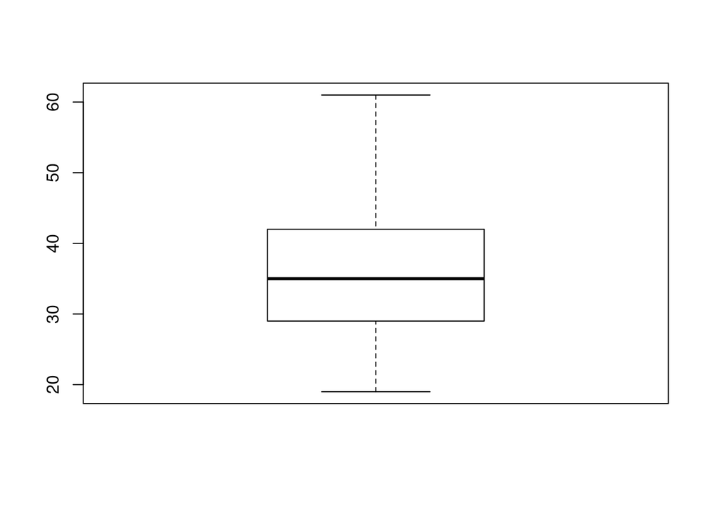

```r
boxplot(advertising_dataset$Age)
```